# Statistikos 1 laboratorinis darbas: Matematinė statistika

2025-03-12

### 1. Aprašykite nagrinėjamo a.d. skirstinį. Pateikite pavyzdžių, kur jis taikomas.

Logistinis skirstinys yra simetriškas, turi vieną viršūnę ir savo forma panašus į normalųjį pasiskirstymą, centruotas aplink $\mu$, pasiskirstymas priklauso nuo nuo $\sigma$ parametro.[^1]

### 3. Užrašykite kam lygūs šio a.d. vidurkis, dispersija asimetrijos ir eksceso koeficientai.

• Vidurkis $\mu$

• Asimetrijos koeficientas 0

• Eksceso koeficientas 6/5

### 4. Išbrėžkite a.d. tankio (tikimybių) ir pasiskirstymo funkcijos grafikus su skirtingais parametrų rinkiniais. Kaip parametrai keičia tankio funkcijų (tikimybių) formas?

Pasirinkti parametrų rinkiniai:

```
location = 0, scale = 1;
location = 4 , scale = 2;
location = 8, scale = 3.
```

Tankio grafikų vizualizavimas

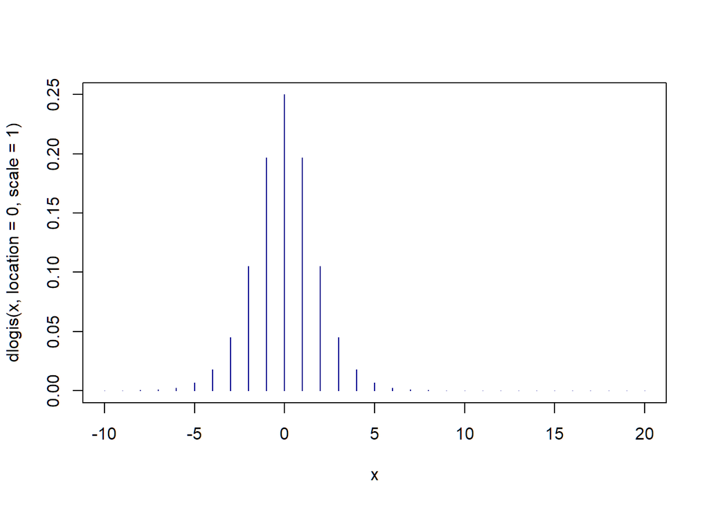

```r
x <- -10:20
plot(x, dlogis(x, location = 0, scale = 1), type = "h", col = "darkblue")
```

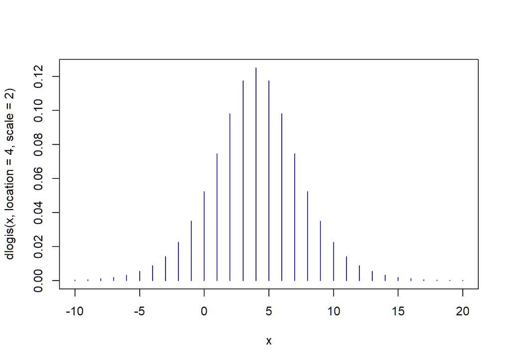

```r
plot(x, dlogis(x, location = 4, scale = 2), type = "h", col = "darkblue")
```

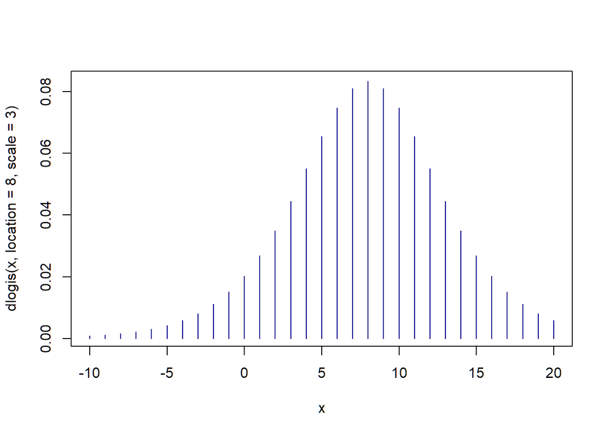

```r
plot(x, dlogis(x, location = 8, scale = 3), type = "h", col = "darkblue")
```

Pasiskirstymo grafikų vizualizavimas

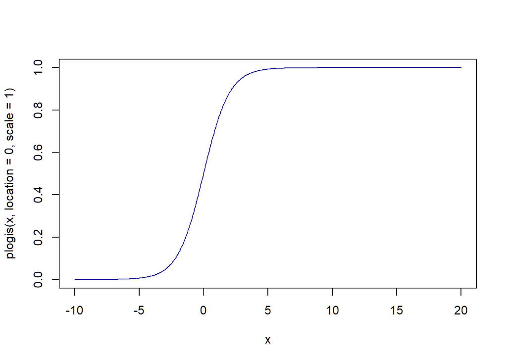

```r
x <- seq(-10, 20, by=0.05)
plot(x, plogis(x, location = 0, scale = 1), type = "l", col = "darkblue")
```

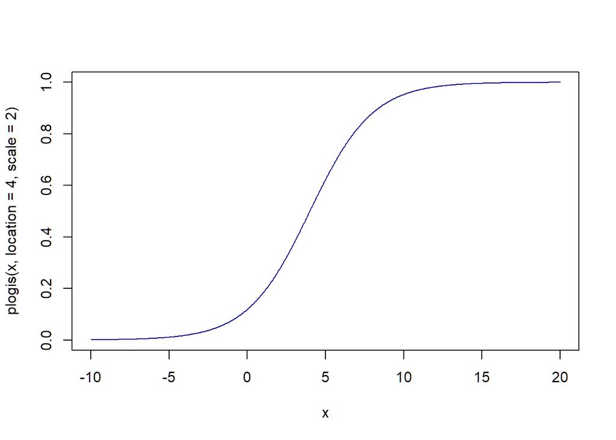

```r
plot(x, plogis(x, location = 4, scale = 2), type = "l", col = "darkblue")
```

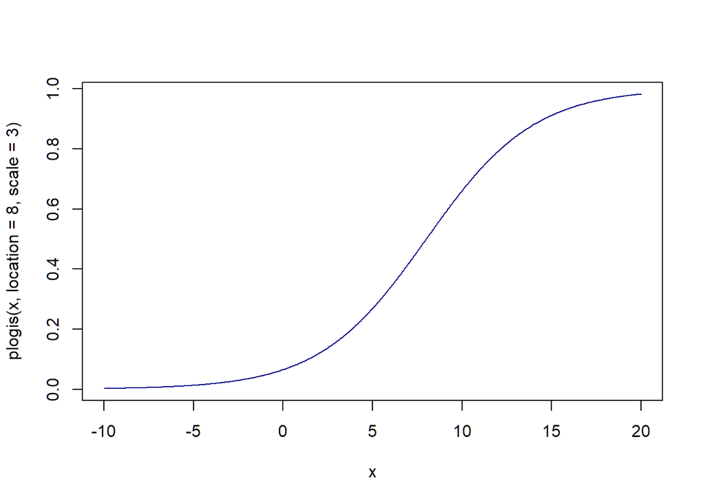

```r
plot(x, plogis(x, location = 8, scale = 3), type = "l", col = "darkblue")
```

### 5. Užrašykite kvantilių funkciją ir išbrėžkite jos grafiką su skirtingais parametrais. Kaip keičiasi kvantilių grafikas, keičiant parametrus?

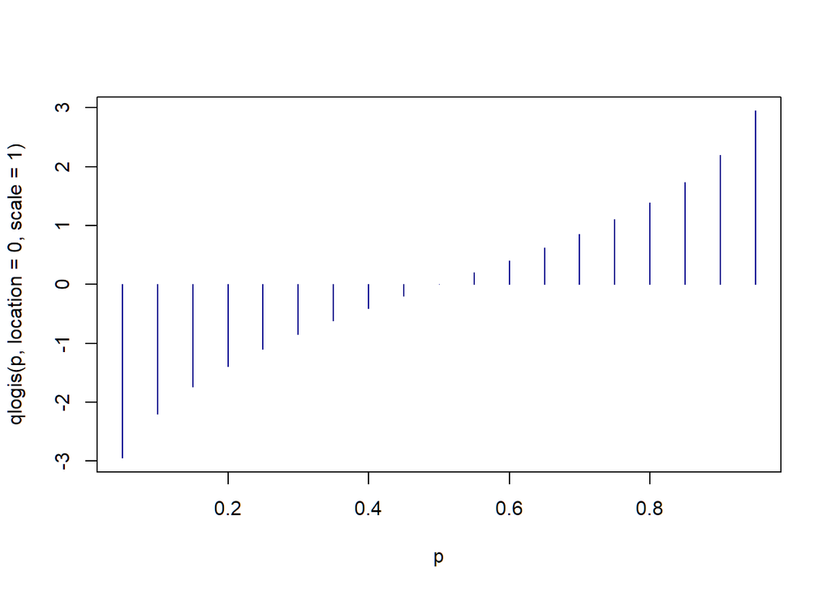

```r
p <- seq(0.05,0.95,by = 0.05)
plot(p, qlogis(p, location = 0, scale = 1), type = "h", col = "darkblue")
```

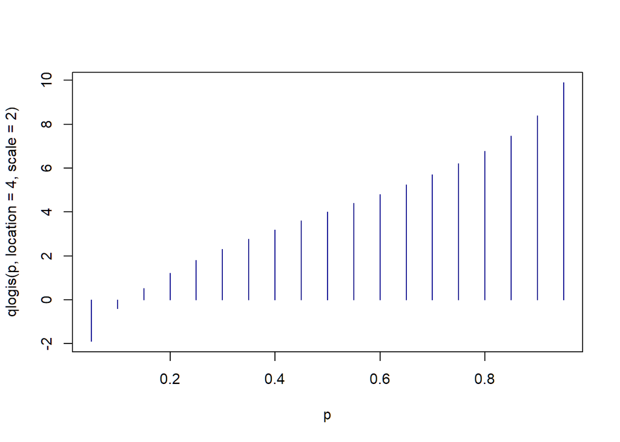

```r
plot(p, qlogis(p, location = 4, scale = 2), type = "h", col = "darkblue")
```

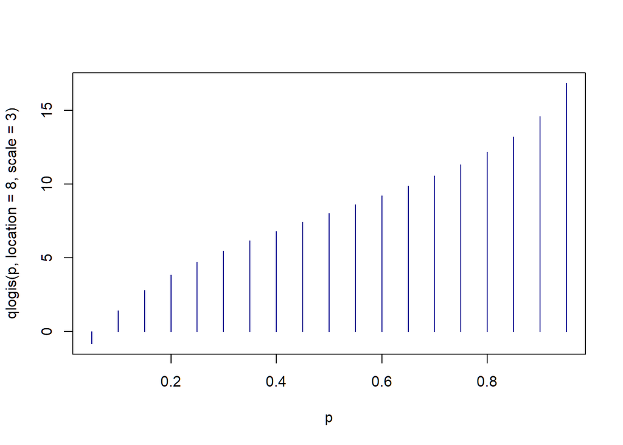

```r
plot(p, qlogis(p, location = 8, scale = 3), type = "h", col = "darkblue")
```

### 6. Fiksuokite vieną, pasirinktą a.d. parametrų rinkinį. Sugeneruokite iš savo skirstinio duomenų rinkinius su 20, 50, 200, 1000 imčių dydžiais:

```r
location <- 4
scale <- 2
n<-c(20, 50, 200, 1000)
set.seed(58)
x1<-rlogis(n[1], location, scale)
set.seed(58)
x2<-rlogis(n[2], location, scale)
set.seed(58)
x3<-rlogis(n[3], location, scale)
set.seed(58)
x4<-rlogis(n[4], location, scale)
```

#### 6.1 Nubrėžkite histogramas (stulpelių diagramas).

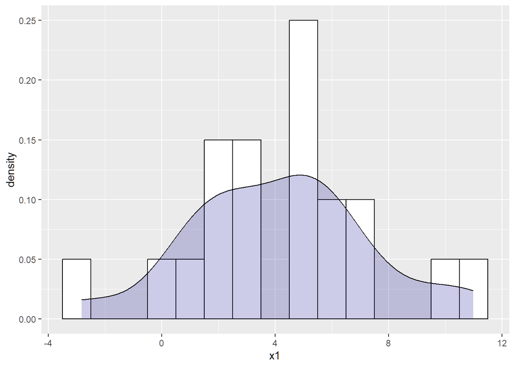

```r
library(ggplot2)
histograma1 <- ggplot(data.frame(x1), aes(x=x1)) +
  geom_histogram(aes(y=after_stat(density)), binwidth = 1,
                 colour="black", fill="white") +
  geom_density(alpha=.2, fill="darkblue")
histograma1
```

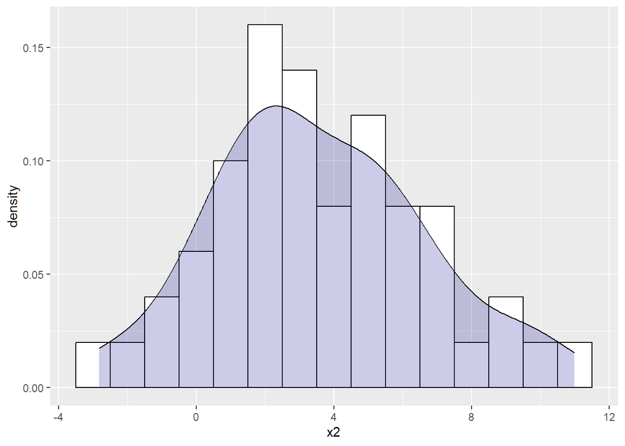

```r
histograma2 <- ggplot(data.frame(x2), aes(x=x2)) +
  geom_histogram(aes(y=after_stat(density)), binwidth = 1,
                 colour="black", fill="white") +
  geom_density(alpha=.2, fill="darkblue")
histograma2
```

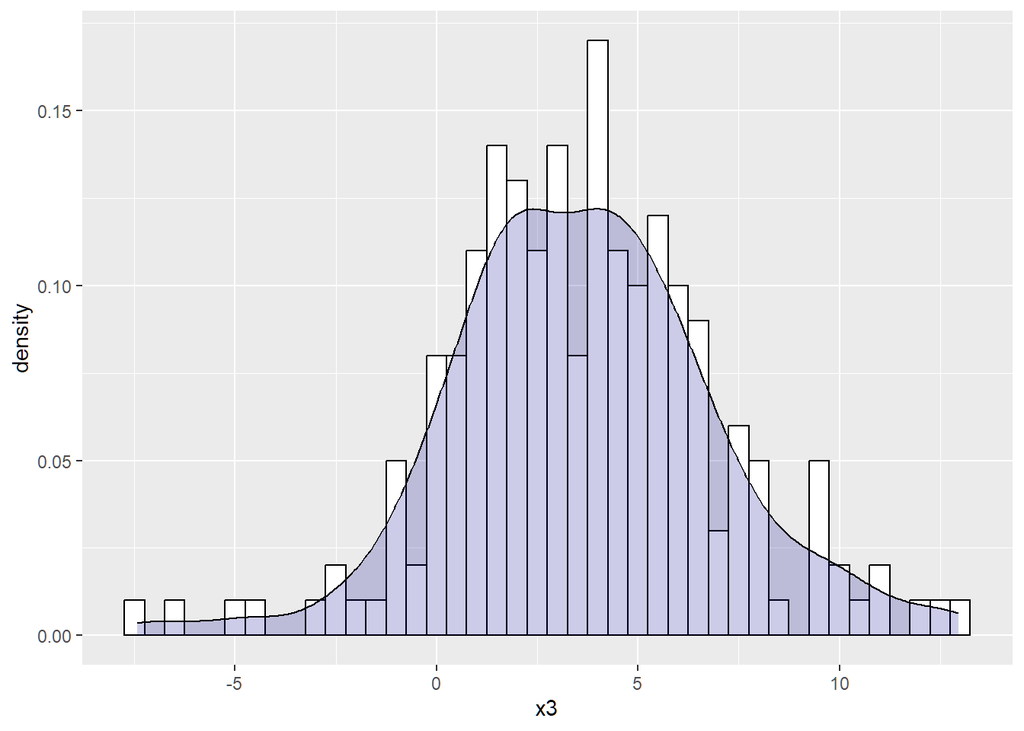

```r
histograma3 <- ggplot(data.frame(x3), aes(x=x3)) +
  geom_histogram(aes(y=after_stat(density)), binwidth = 0.5,
                 colour="black", fill="white") +
  geom_density(alpha=.2, fill="darkblue")
histograma3
```

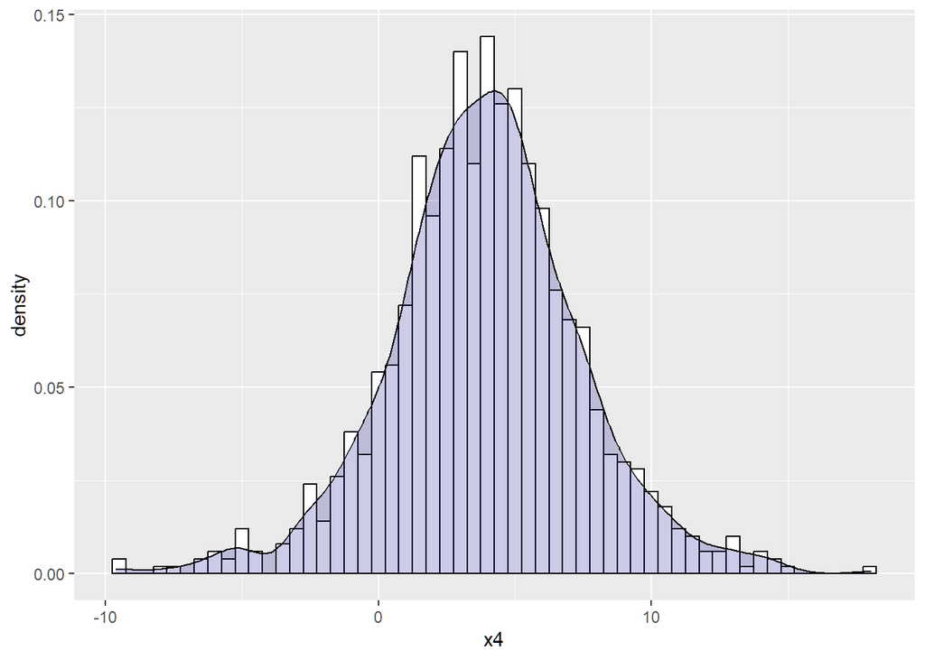

```r
histograma4 <- ggplot(data.frame(x4), aes(x=x4)) +
  geom_histogram(aes(y=after_stat(density)), binwidth = 0.5,
                 colour="black", fill="white") +
  geom_density(alpha=.2, fill="darkblue")
histograma4
```

#### 6.2 Nubrėžkite empirines pasiskirstymo funkcijas.

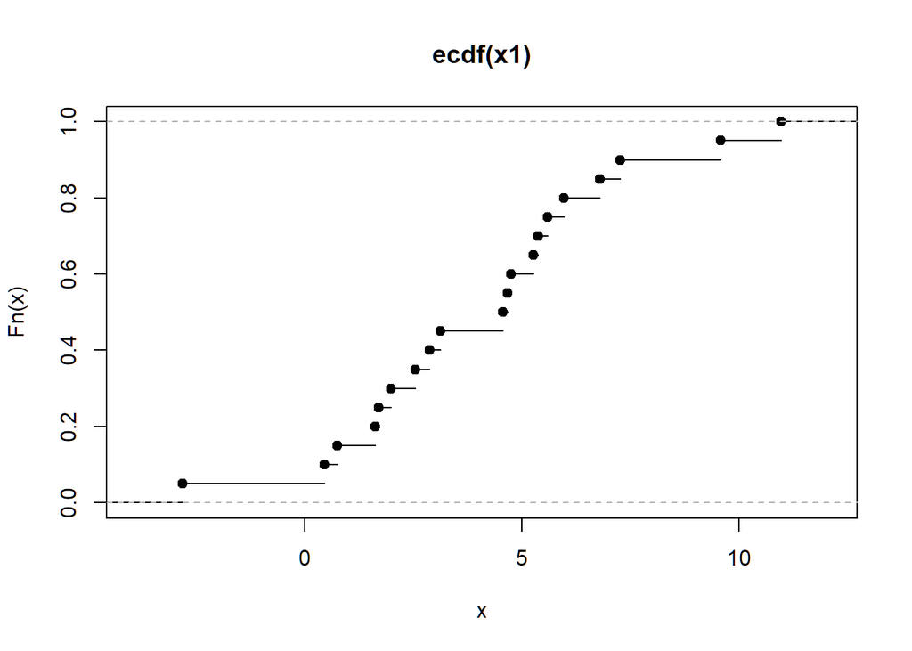

```r
ex1 <- ecdf(x1)
plot(ex1)
```

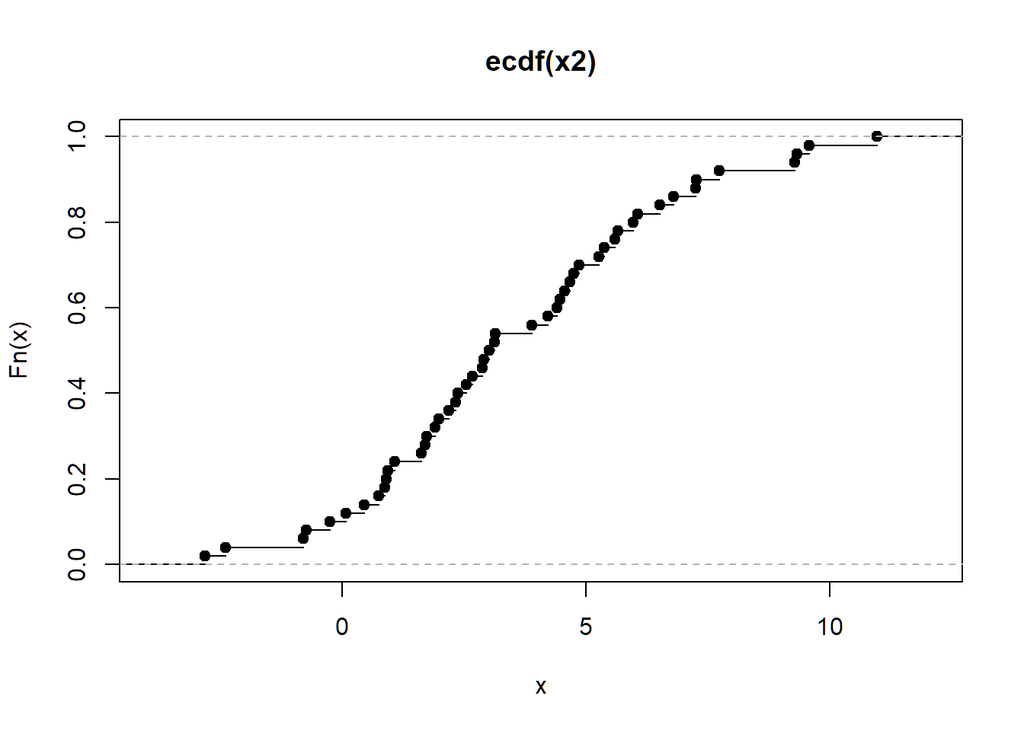

```r
ex2 <- ecdf(x2)
plot(ex2)
```

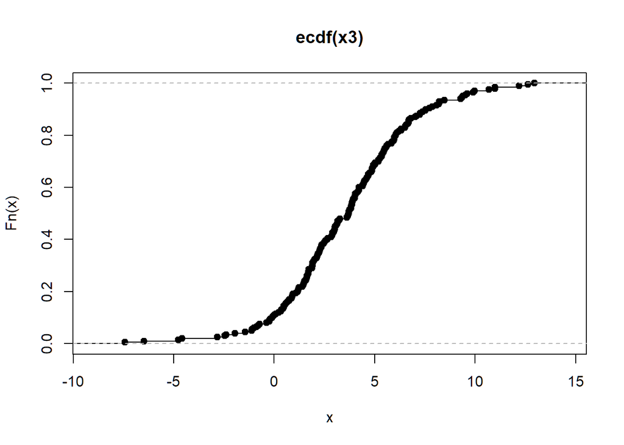

```r
ex3 <- ecdf(x3)
plot(ex3)
```

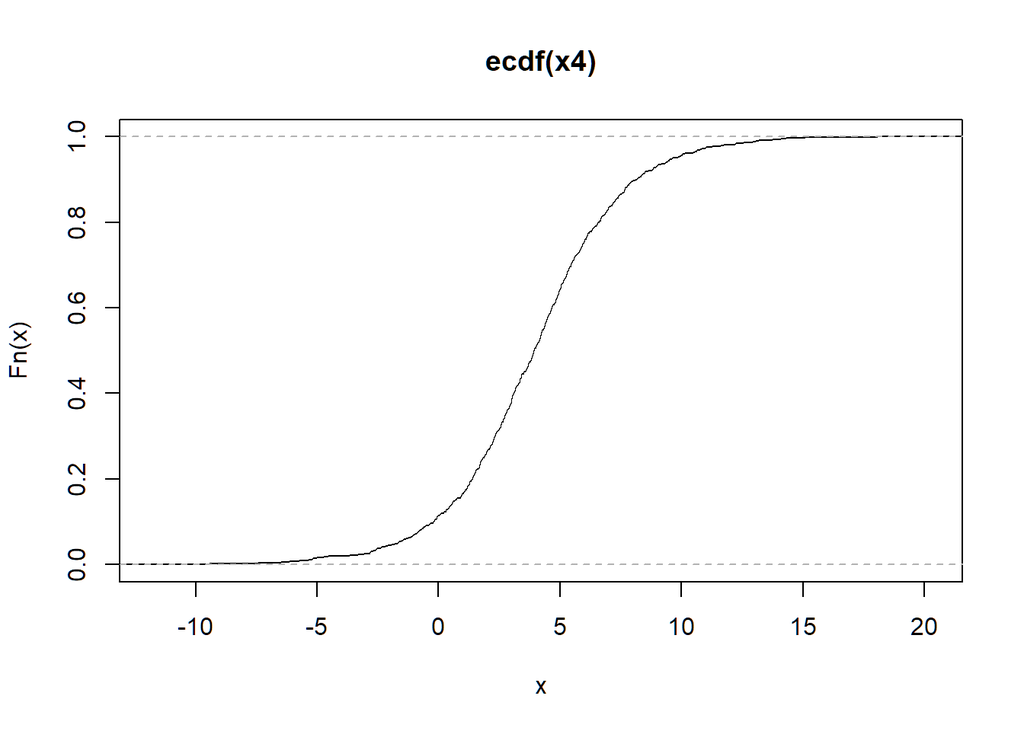

```r
ex4 <- ecdf(x4)
plot(ex4)
```